# This is a dataset containing details on different characteristics of movies as compiled by a movies review site IMDB

## The data has 10866 row entries all classified under 21 columns. The dataset contains information on the id, imdb_id, popularity, budget, revenue, original title, cast, homepage, director, tagline, keywords, overview, runtime, genres, production companies, release date, vote count,vote average, release year, budget adjustments, revenue adjustments

```python
import pandas as pd
import matplotlib.pyplot as plt
import numpy as np
import seaborn as sns
Movies_df = pd.read_csv('tmdb-movies.csv')
df=Movies_df.copy()
```

```python
df.head()
```

|  | id | imdb_id | popularity | budget | revenue | original_title | cast | homepage | director | tagline | ... | overview | runtime | genres | production_companies | release_date | vote_count | vote_average | release_year | budget_adj | revenue_adj |
| --- | --- | --- | --- | --- | --- | --- | --- | --- | --- | --- | --- | --- | --- | --- | --- | --- | --- | --- | --- | --- | --- |
| 0 | 135397 | tt0369610 | 32.985763 | 150000000 | 1513528810 | Jurassic World | Chris Pratt\|Bryce Dallas Howard\|Irrfan Khan\|Vi... | http://www.jurassicworld.com/ | Colin Trevorrow | The park is open. | ... | Twenty-two years after the events of Jurassic ... | 124 | Action\|Adventure\|Science Fiction\|Thriller | Universal Studios\|Amblin Entertainment\|Legenda... | 6/9/15 | 5562 | 6.5 | 2015 | 1.379999e+08 | 1.392446e+09 |
| 1 | 76341 | tt1392190 | 28.419936 | 150000000 | 378436354 | Mad Max: Fury Road | Tom Hardy\|Charlize Theron\|Hugh Keays-Byrne\|Nic... | http://www.madmaxmovie.com/ | George Miller | What a Lovely Day. | ... | An apocalyptic story set in the furthest reach... | 120 | Action\|Adventure\|Science Fiction\|Thriller | Village Roadshow Pictures\|Kennedy Miller Produ... | 5/13/15 | 6185 | 7.1 | 2015 | 1.379999e+08 | 3.481613e+08 |
| 2 | 262500 | tt2908446 | 13.112507 | 110000000 | 295238201 | Insurgent | Shailene Woodley\|Theo James\|Kate Winslet\|Ansel... | http://www.thedivergentseries.movie/#insurgent | Robert Schwentke | One Choice Can Destroy You | ... | Beatrice Prior must confront her inner demons ... | 119 | Adventure\|Science Fiction\|Thriller | Summit Entertainment\|Mandeville Films\|Red Wago... | 3/18/15 | 2480 | 6.3 | 2015 | 1.012000e+08 | 2.716190e+08 |
| 3 | 140607 | tt2488496 | 11.173104 | 200000000 | 2068178225 | Star Wars: The Force Awakens | Harrison Ford\|Mark Hamill\|Carrie Fisher\|Adam D... | http://www.starwars.com/films/star-wars-episod... | J.J. Abrams | Every generation has a story. | ... | Thirty years after defeating the Galactic Empi... | 136 | Action\|Adventure\|Science Fiction\|Fantasy | Lucasfilm\|Truenorth Productions\|Bad Robot | 12/15/15 | 5292 | 7.5 | 2015 | 1.839999e+08 | 1.902723e+09 |
| 4 | 168259 | tt2820852 | 9.335014 | 190000000 | 1506249360 | Furious 7 | Vin Diesel\|Paul Walker\|Jason Statham\|Michelle ... | http://www.furious7.com/ | James Wan | Vengeance Hits Home | ... | Deckard Shaw seeks revenge against Dominic Tor... | 137 | Action\|Crime\|Thriller | Universal Pictures\|Original Film\|Media Rights ... | 4/1/15 | 2947 | 7.3 | 2015 | 1.747999e+08 | 1.385749e+09 |

5 rows × 21 columns

Then checking for rhe total amount of rows and columns our dataset contains using the .shape method

```python
df.shape
```

```
(10866, 21)
```

while answering these questions there are some columns that are not needed like the tagline, homepage and overview, so removing this column from our dataset

```python
df.drop(['tagline', 'homepage', 'overview', 'keywords','id'], axis=1, inplace = True)
df.drop_duplicates(inplace=True)
sum(df.duplicated())
df.info()
```

```
<class 'pandas.core.frame.DataFrame'>
Int64Index: 10865 entries, 0 to 10865
Data columns (total 16 columns):
imdb_id                 10855 non-null object
popularity              10865 non-null float64
budget                  10865 non-null int64
revenue                 10865 non-null int64
original_title          10865 non-null object
cast                    10789 non-null object
director                10821 non-null object
runtime                 10865 non-null int64
genres                  10842 non-null object
production_companies    9835 non-null object
release_date            10865 non-null object
vote_count              10865 non-null int64
vote_average            10865 non-null float64
release_year            10865 non-null int64
budget_adj              10865 non-null float64
revenue_adj             10865 non-null float64
dtypes: float64(4), int64(5), object(7)
memory usage: 1.4+ MB
```

```python
df.dropna(inplace=True)
df.info()
```

```
<class 'pandas.core.frame.DataFrame'>
Int64Index: 9770 entries, 0 to 10865
Data columns (total 16 columns):
imdb_id                 9770 non-null object
popularity              9770 non-null float64
budget                  9770 non-null int64
revenue                 9770 non-null int64
original_title          9770 non-null object
cast                    9770 non-null object
director                9770 non-null object
runtime                 9770 non-null int64
genres                  9770 non-null object
production_companies    9770 non-null object
release_date            9770 non-null object
vote_count              9770 non-null int64
vote_average            9770 non-null float64
release_year            9770 non-null int64
budget_adj              9770 non-null float64
revenue_adj             9770 non-null float64
dtypes: float64(4), int64(5), object(7)
memory usage: 1.3+ MB
```

```python
df['release_year'] = pd.to_datetime(df['release_year'])
```

```python
df['release_date'] = pd.to_datetime(df['release_date'], format='%m/%d/%y')
df['release_date']
```

```
0       2015-06-09
1       2015-05-13
2       2015-03-18
3       2015-12-15
4       2015-04-01
           ...
10861   2066-06-15
10862   2066-12-21
10863   2066-01-01
10864   2066-11-02
10865   2066-11-15
Name: release_date, Length: 9770, dtype: datetime64[ns]
```

# Next checking for missing values in our dataset

```python
df.head(10)
```

|  | imdb_id | popularity | budget | revenue | original_title | cast | director | runtime | genres | production_companies | release_date | vote_count | vote_average | release_year | budget_adj | revenue_adj |
| --- | --- | --- | --- | --- | --- | --- | --- | --- | --- | --- | --- | --- | --- | --- | --- | --- |
| 0 | tt0369610 | 32.985763 | 150000000 | 1513528810 | Jurassic World | Chris Pratt\|Bryce Dallas Howard\|Irrfan Khan\|Vi... | Colin Trevorrow | 124 | Action\|Adventure\|Science Fiction\|Thriller | Universal Studios\|Amblin Entertainment\|Legenda... | 2015-06-09 | 5562 | 6.5 | 1970-01-01 00:00:00.000002015 | 1.379999e+08 | 1.392446e+09 |
| 1 | tt1392190 | 28.419936 | 150000000 | 378436354 | Mad Max: Fury Road | Tom Hardy\|Charlize Theron\|Hugh Keays-Byrne\|Nic... | George Miller | 120 | Action\|Adventure\|Science Fiction\|Thriller | Village Roadshow Pictures\|Kennedy Miller Produ... | 2015-05-13 | 6185 | 7.1 | 1970-01-01 00:00:00.000002015 | 1.379999e+08 | 3.481613e+08 |
| 2 | tt2908446 | 13.112507 | 110000000 | 295238201 | Insurgent | Shailene Woodley\|Theo James\|Kate Winslet\|Ansel... | Robert Schwentke | 119 | Adventure\|Science Fiction\|Thriller | Summit Entertainment\|Mandeville Films\|Red Wago... | 2015-03-18 | 2480 | 6.3 | 1970-01-01 00:00:00.000002015 | 1.012000e+08 | 2.716190e+08 |
| 3 | tt2488496 | 11.173104 | 200000000 | 2068178225 | Star Wars: The Force Awakens | Harrison Ford\|Mark Hamill\|Carrie Fisher\|Adam D... | J.J. Abrams | 136 | Action\|Adventure\|Science Fiction\|Fantasy | Lucasfilm\|Truenorth Productions\|Bad Robot | 2015-12-15 | 5292 | 7.5 | 1970-01-01 00:00:00.000002015 | 1.839999e+08 | 1.902723e+09 |
| 4 | tt2820852 | 9.335014 | 190000000 | 1506249360 | Furious 7 | Vin Diesel\|Paul Walker\|Jason Statham\|Michelle ... | James Wan | 137 | Action\|Crime\|Thriller | Universal Pictures\|Original Film\|Media Rights ... | 2015-04-01 | 2947 | 7.3 | 1970-01-01 00:00:00.000002015 | 1.747999e+08 | 1.385749e+09 |
| 5 | tt1663202 | 9.110700 | 135000000 | 532950503 | The Revenant | Leonardo DiCaprio\|Tom Hardy\|Will Poulter\|Domhn... | Alejandro González Iñárritu | 156 | Western\|Drama\|Adventure\|Thriller | Regency Enterprises\|Appian Way\|CatchPlay\|Anony... | 2015-12-25 | 3929 | 7.2 | 1970-01-01 00:00:00.000002015 | 1.241999e+08 | 4.903142e+08 |
| 6 | tt1340138 | 8.654359 | 155000000 | 440603537 | Terminator Genisys | Arnold Schwarzenegger\|Jason Clarke\|Emilia Clar... | Alan Taylor | 125 | Science Fiction\|Action\|Thriller\|Adventure | Paramount Pictures\|Skydance Productions | 2015-06-23 | 2598 | 5.8 | 1970-01-01 00:00:00.000002015 | 1.425999e+08 | 4.053551e+08 |
| 7 | tt3659388 | 7.667400 | 108000000 | 595380321 | The Martian | Matt Damon\|Jessica Chastain\|Kristen Wiig\|Jeff ... | Ridley Scott | 141 | Drama\|Adventure\|Science Fiction | Twentieth Century Fox Film Corporation\|Scott F... | 2015-09-30 | 4572 | 7.6 | 1970-01-01 00:00:00.000002015 | 9.935996e+07 | 5.477497e+08 |
| 8 | tt2293640 | 7.404165 | 74000000 | 1156730962 | Minions | Sandra Bullock\|Jon Hamm\|Michael Keaton\|Allison... | Kyle Balda\|Pierre Coffin | 91 | Family\|Animation\|Adventure\|Comedy | Universal Pictures\|Illumination Entertainment | 2015-06-17 | 2893 | 6.5 | 1970-01-01 00:00:00.000002015 | 6.807997e+07 | 1.064192e+09 |
| 9 | tt2096673 | 6.326804 | 175000000 | 853708609 | Inside Out | Amy Poehler\|Phyllis Smith\|Richard Kind\|Bill Ha... | Pete Docter | 94 | Comedy\|Animation\|Family | Walt Disney Pictures\|Pixar Animation Studios\|W... | 2015-06-09 | 3935 | 8.0 | 1970-01-01 00:00:00.000002015 | 1.609999e+08 | 7.854116e+08 |

now checking for the actors that were present in the movies and the number of movies they acted in

```python
actors_lists = []
for lis in df.cast.str.split('|'):
    actors_lists.append(lis)

new_list_actor = []
for sub_list in actors_lists:
    for name in sub_list:
        new_list_actor.append(name)
no=[]
n_lists={}
for directo in new_list_actor:
    no.append(directo)
for name in no:
    if name in n_lists:
        n_lists[name] += 1
    else:
        n_lists[name] = 1

actors = pd.DataFrame.from_dict(n_lists, orient= 'index')
actors = actors.reset_index()
actors.columns = ['name', 'n0_of_movies']
actors.sort_values('n0_of_movies', ascending = False)
```

|  | name | n0_of_movies |
| --- | --- | --- |
| 233 | Robert De Niro | 72 |
| 73 | Samuel L. Jackson | 70 |
| 401 | Bruce Willis | 62 |
| 629 | Nicolas Cage | 61 |
| 133 | Michael Caine | 52 |
| ... | ... | ... |
| 9567 | Aya Endo | 1 |
| 9568 | Rie Kugimiya | 1 |
| 9569 | Yuichi Nakamura | 1 |
| 9570 | Aya Hirano | 1 |
| 17122 | Stephanie Nielson | 1 |

17123 rows × 2 columns

```python
lists = []
new_list_genre = []

for lis in df.genres.str.split('|'):
    lists.append(lis)
for sub_list in lists:
    for name in sub_list:
        new_list_genre.append(name.lower())
```

to see the number of movies with different genre

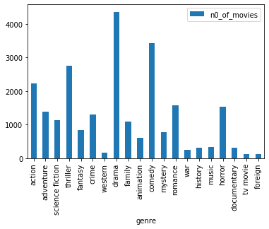

```python
genre ={}
for gene in new_list_genre:
    genre.setdefault(gene, 0)
    genre[gene] +=1
genre = pd.DataFrame.from_dict(genre, orient='index')
# genre.plot(kind='bar')
genre = genre.reset_index()
genre.columns = ['genre', 'n0_of_movies']
genre.sort_values('n0_of_movies', ascending = False)
genre.head()

genre.plot(x='genre', y='n0_of_movies', kind='bar');
```

```python
df.describe().vote_average
```

```
count    9770.000000
mean        5.963388
std         0.913207
min         1.500000
25%         5.400000
50%         6.000000
75%         6.600000
max         8.700000
Name: vote_average, dtype: float64
```

```python
df.head()
```

|  | imdb_id | popularity | budget | revenue | original_title | cast | director | runtime | genres | production_companies | release_date | vote_count | vote_average | release_year | budget_adj | revenue_adj |
| --- | --- | --- | --- | --- | --- | --- | --- | --- | --- | --- | --- | --- | --- | --- | --- | --- |
| 0 | tt0369610 | 32.985763 | 150000000 | 1513528810 | Jurassic World | Chris Pratt\|Bryce Dallas Howard\|Irrfan Khan\|Vi... | Colin Trevorrow | 124 | Action\|Adventure\|Science Fiction\|Thriller | Universal Studios\|Amblin Entertainment\|Legenda... | 2015-06-09 | 5562 | 6.5 | 1970-01-01 00:00:00.000002015 | 1.379999e+08 | 1.392446e+09 |
| 1 | tt1392190 | 28.419936 | 150000000 | 378436354 | Mad Max: Fury Road | Tom Hardy\|Charlize Theron\|Hugh Keays-Byrne\|Nic... | George Miller | 120 | Action\|Adventure\|Science Fiction\|Thriller | Village Roadshow Pictures\|Kennedy Miller Produ... | 2015-05-13 | 6185 | 7.1 | 1970-01-01 00:00:00.000002015 | 1.379999e+08 | 3.481613e+08 |
| 2 | tt2908446 | 13.112507 | 110000000 | 295238201 | Insurgent | Shailene Woodley\|Theo James\|Kate Winslet\|Ansel... | Robert Schwentke | 119 | Adventure\|Science Fiction\|Thriller | Summit Entertainment\|Mandeville Films\|Red Wago... | 2015-03-18 | 2480 | 6.3 | 1970-01-01 00:00:00.000002015 | 1.012000e+08 | 2.716190e+08 |
| 3 | tt2488496 | 11.173104 | 200000000 | 2068178225 | Star Wars: The Force Awakens | Harrison Ford\|Mark Hamill\|Carrie Fisher\|Adam D... | J.J. Abrams | 136 | Action\|Adventure\|Science Fiction\|Fantasy | Lucasfilm\|Truenorth Productions\|Bad Robot | 2015-12-15 | 5292 | 7.5 | 1970-01-01 00:00:00.000002015 | 1.839999e+08 | 1.902723e+09 |
| 4 | tt2820852 | 9.335014 | 190000000 | 1506249360 | Furious 7 | Vin Diesel\|Paul Walker\|Jason Statham\|Michelle ... | James Wan | 137 | Action\|Crime\|Thriller | Universal Pictures\|Original Film\|Media Rights ... | 2015-04-01 | 2947 | 7.3 | 1970-01-01 00:00:00.000002015 | 1.747999e+08 | 1.385749e+09 |

## From this visualization we can see that the more popular a movie was the more money they had to spend on their budget, we can say that maybe advertisement contributed to the high budget required intially for the movie as the chart shows an exponential increase in budget for popularity

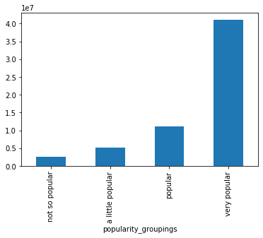

```python
cuts = [0, 0.207, 0.384, 0.714, 32.99]
cut_names = ['not so popular', 'a little popular', 'popular', 'very popular']
df['popularity_groupings'] = pd.cut(df['popularity'], cuts, labels=cut_names)
df.groupby('popularity_groupings').budget.mean().plot(kind='bar')
```

```python
df_r = df.query('runtime>112 & runtime<150')
df_r.shape
```

```
(2096, 17)
```

## From the pie chart brlow we are able to visualize the effect of movies length on the popularity of movies and we see that the most popular ovies are those with the designation standard length which have a runtime between the range of 112 and 180 minutes.

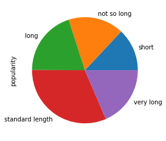

```python
cuts = [0, 90, 100, 112, 180, 877]
cut_names = ['short', 'not so long', 'long','standard length', 'very long']
df['movie_length'] = pd.cut(df['runtime'], cuts, labels=cut_names)
df.groupby('movie_length').popularity.mean().plot(kind='pie')
```

```python
df['profit'] = df['revenue'] - df['budget']
```

```python
df_p = df[['budget', 'revenue', 'profit']]
```

plot of budget against profit shows a somewhat positive correlation

## The bar chart below shows that the popular movies are the ones that bring about the most profit

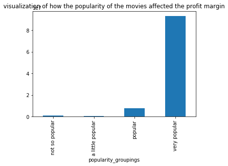

```python
df.groupby('popularity_groupings').profit.mean().plot(kind='bar', title='visualization of how the popularity of the movies affected the profit margin');
# plt.xlabel('popularity', fontsize=18)
# plt.ylabel('profit', fo|ntsize=18)
```

```python
df.head()
```

|  | imdb_id | popularity | budget | revenue | original_title | cast | director | runtime | genres | production_companies | release_date | vote_count | vote_average | release_year | budget_adj | revenue_adj | popularity_groupings | movie_length | profit |
| --- | --- | --- | --- | --- | --- | --- | --- | --- | --- | --- | --- | --- | --- | --- | --- | --- | --- | --- | --- |
| 0 | tt0369610 | 32.985763 | 150000000 | 1513528810 | Jurassic World | Chris Pratt\|Bryce Dallas Howard\|Irrfan Khan\|Vi... | Colin Trevorrow | 124 | Action\|Adventure\|Science Fiction\|Thriller | Universal Studios\|Amblin Entertainment\|Legenda... | 2015-06-09 | 5562 | 6.5 | 1970-01-01 00:00:00.000002015 | 1.379999e+08 | 1.392446e+09 | very popular | standard length | 1363528810 |
| 1 | tt1392190 | 28.419936 | 150000000 | 378436354 | Mad Max: Fury Road | Tom Hardy\|Charlize Theron\|Hugh Keays-Byrne\|Nic... | George Miller | 120 | Action\|Adventure\|Science Fiction\|Thriller | Village Roadshow Pictures\|Kennedy Miller Produ... | 2015-05-13 | 6185 | 7.1 | 1970-01-01 00:00:00.000002015 | 1.379999e+08 | 3.481613e+08 | very popular | standard length | 228436354 |
| 2 | tt2908446 | 13.112507 | 110000000 | 295238201 | Insurgent | Shailene Woodley\|Theo James\|Kate Winslet\|Ansel... | Robert Schwentke | 119 | Adventure\|Science Fiction\|Thriller | Summit Entertainment\|Mandeville Films\|Red Wago... | 2015-03-18 | 2480 | 6.3 | 1970-01-01 00:00:00.000002015 | 1.012000e+08 | 2.716190e+08 | very popular | standard length | 185238201 |
| 3 | tt2488496 | 11.173104 | 200000000 | 2068178225 | Star Wars: The Force Awakens | Harrison Ford\|Mark Hamill\|Carrie Fisher\|Adam D... | J.J. Abrams | 136 | Action\|Adventure\|Science Fiction\|Fantasy | Lucasfilm\|Truenorth Productions\|Bad Robot | 2015-12-15 | 5292 | 7.5 | 1970-01-01 00:00:00.000002015 | 1.839999e+08 | 1.902723e+09 | very popular | standard length | 1868178225 |
| 4 | tt2820852 | 9.335014 | 190000000 | 1506249360 | Furious 7 | Vin Diesel\|Paul Walker\|Jason Statham\|Michelle ... | James Wan | 137 | Action\|Crime\|Thriller | Universal Pictures\|Original Film\|Media Rights ... | 2015-04-01 | 2947 | 7.3 | 1970-01-01 00:00:00.000002015 | 1.747999e+08 | 1.385749e+09 | very popular | standard length | 1316249360 |

## The scatter plot and the box plot show a mainly positive trendline with there generally being a profit for the budget put in with a negligible amount of movies turning up a loss.

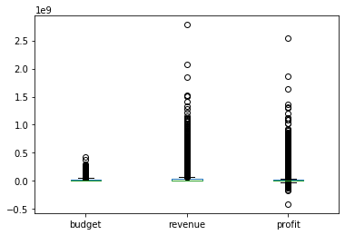

```python
df_p.plot(kind='box')
```

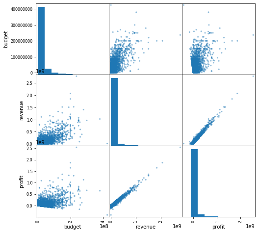

```python
pd.plotting.scatter_matrix(df_p, figsize=(8,8));
```

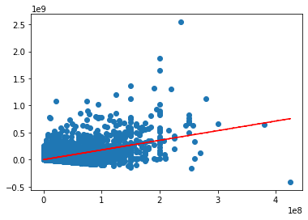

```python
x=df_p['budget']
y =df_p['profit']
plt.scatter(x,y)
z = np.polyfit(x, y, 1)
p = np.poly1d(z)
plt.plot(x, p(x), 'r--')
plt.show()
```